# R Notebook

# Hypothesis Testing

## Chi-Square Test

Is there a relationship between playoff appearances and being above the CBT threshold? A chi-square test would be appropriate for this scenario. The null hypothesis is that making the playoffs and being above the CBT threshold are independent. The alternative hypothesis is that those two variables are not independent (there is some relationship between the two).

```r
chisq.test(payroll$playoffs, payroll$above_cbt)
```

```
    Pearson's Chi-squared test with Yates' continuity correction

data:  payroll$playoffs and payroll$above_cbt
X-squared = 25.237, df = 1, p-value = 5.07e-07
```

The p-value for this test is essentially 0. We can reject the null hypothesis and conclude that playoff appearances and being above the CBT threshold are not independent, there is some relationship between the two. Conventional wisdom would say that this relationship is a postive one in the sense that being above the threshold makes a team more likely to make the playoffs. Now it would be useful to confirm that intuition and if it is true, then quantify just how much of an advantage being above the threshold gives to a team.

## Independent t-test

Is the average winning percentage for teams below the CBT threshold smaller than the average winning percentage for teams above the CBT threshold?

Let $\mu_a$ = mean winning percentage for teams *above* the CBT threshold.

Let $\mu_b$ = mean winning percentage for teams *below* CBT threshold.

$H_0 = \mu_a - \mu_b \le 0$

$H_a = \mu_a - \mu_b > 0$

```r
above <- payroll[payroll$above_cbt == 1, "wpct"]
below <- payroll[payroll$above_cbt == 0, "wpct"]
t.test(above, below,
       alternative = "greater",
       conf.level = 0.95)
```

```
    Welch Two Sample t-test

data:  above and below
t = 6.9636, df = 37.794, p-value = 1.417e-08
alternative hypothesis: true difference in means is greater than 0
95 percent confidence interval:
 0.05750915        Inf
sample estimates:
mean of x mean of y
0.5716970 0.4958131
```

The p-value from this t-test is essentially 0. We have enough evidence to reject the null hypothesis, teams with a payroll above the CBT threshold have a higher winning percentage than teams below the CBT threshold. We are 95% confident that the true difference of means between the winning percentage of the two populations is greater than 0.0575. This works out to a difference of 9.3 wins over an entire 162 game season, meaning we are 95% confident that teams who exceed the CBT threshold win at least 9 more games than teams that do not.

# Population

Is there a relationship between population and winning percentage? What about population and payroll? Is this a problem that is difficult to address because teams in bigger cities are better, not teams with wealthier owners?

## Chi-Square Test

Let’s start by doing the same tests as earlier, but using a team’s market size as a variable instead of their payroll size. First we repeat the chi-square test. The null hypothesis is that making the playoffs and being a large market team independent. The alternative hypothesis is that those two variables are not independent (there is some relationship between the two).

```r
chisq.test(payroll$playoffs, payroll$large_market)
```

```
    Pearson's Chi-squared test with Yates' continuity correction

data:  payroll$playoffs and payroll$large_market
X-squared = 3.5825, df = 1, p-value = 0.05839
```

It is close, but a p-value of 0.058 means we cannot reject the null hypothesis at a 95% confidence level. We cannot conclude that there is a relationship between being a large market team and making the playoffs. Since we could reject the null hypothesis at a 90% confidence level, it is still worth continuing to the t-test as we did earlier to figure out how much of a difference being a large market team makes.

## Independent t-test

Is the average winning percentage for small market teams smaller than the average winning percentage for large market teams?

Let $\mu_l$ = mean winning percentage for large market teams.

Let $\mu_s$ = mean winning percentage for small market teams.

$H_0 = \mu_l - \mu_s \le 0$

$H_a = \mu_l - \mu_s > 0$

```r
above <- payroll[payroll$large_market == 1, "wpct"]
below <- payroll[payroll$large_market == 0, "wpct"]
t.test(above, below,
       alternative = "greater",
       conf.level = 0.95)
```

```
    Welch Two Sample t-test

data:  above and below
t = 3.7933, df = 404.46, p-value = 8.568e-05
alternative hypothesis: true difference in means is greater than 0
95 percent confidence interval:
 0.01364837        Inf
sample estimates:
mean of x mean of y
  0.51608   0.49194
```

The p-value for this test is essentially 0. We have enough evidence to reject the null hypothesis and conclude that large market teams have a better mean winning percentage than small market teams. We are 95% confident that the true difference in mean winning percentage between large and small market teams is greater than 0.0136. This works out to a difference of at least 2 wins over an entire 162 game season meaning we are 95% confident that large market teams win at least 2 more games than small market teams on average.

# Bootstrap Methods

As we only have 600 points of data, bootstrapping may be useful here to get more accurate results. Let’s bootstrap the difference of winning percentage means between teams that exceed the CBT threshold and teams that do not.

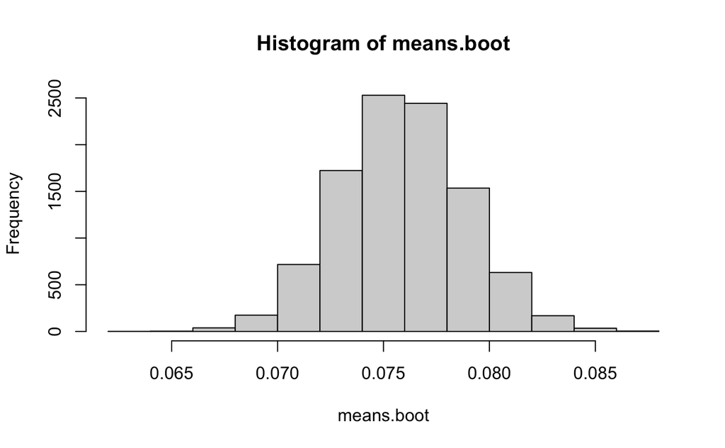

```r
n <- 1000
N <- 10000

means.boot <- numeric(N)

for(i in 1:N){
  x <- sample(payroll$wpct[payroll$above_cbt == 1], n, replace = TRUE)
  y <- sample(payroll$wpct[payroll$above_cbt == 0], n, replace = TRUE)
  means.boot[i] <- mean(x) - mean(y)
}

hist(means.boot)
```

Similar results can be seen here as the earlier t-test, as all differences are greater than 0 and most are around 0.07 and 0.08, showing that teams who surpass the CBT threshold have greater winning percentages than teams that do not.

```r
quantile(means.boot, c(0.025, 0.975)) * 162
```

```
    2.5%    97.5%
11.37384 13.25161
```

We are 95% confident that the true difference in means between winning percentage for teams above and below the CBT threshold is between 11.3 and 13.3 wins each season. This is larger than the previously determined value of 9 wins, further supporting our hypothesis that teams that surpass the CBT threshold win more games.